# Multiple Regression Analysis

yoda

2017년 9월 3일

### 1. 다중회귀분석

단순 회귀 분석의 확장으로 독립 변수(설명 변수)가 2개 이상인 경우를 분석 대상으로 하는 회귀 분석 방법 중 하나이다.

회귀 분석에는 원인이 되는 독립 변수와 결과가 되는 종속 변수가 존재하는데,

이때 종속 변수는 하나이고 독립 변수가 2개 이상인 회귀 모델에 대한 분석을 수행하는 방법이 다중 회귀 분석이다.

본 분석에서는 종속변수를 중고판매가(POSTPRICE)로 설정하고 나머지 컬럼(변수)들을 종속변수를 설명하는

독립변수로 설정을 한다.

분석 후 유의한 회귀식을 도출하여 중고판매가 가격을 예측하고 각 독립변수별 영향력을 살펴본다.

### 2. 데이터 로드 및 확인

```r
data1 <- read.csv("perfact2.csv")
str(data1)
```

```
## 'data.frame':    38912 obs. of  15 variables:
##  $ ID        : int  16186605 16186608 16186617 16186621 16186632 16186644 16186673 16186674 16186678 16186679 ...
##  $ POSTDATE  : Factor w/ 276 levels "2016-11-30","2016-12-01",..: 1 1 1 1 1 1 1 1 1 1 ...
##  $ MODEL     : Factor w/ 13 levels "A1303","A1332",..: 10 13 12 8 11 9 4 10 8 8 ...
##  $ GB        : Factor w/ 6 levels "128GB","16GB",..: 2 1 4 2 5 5 4 5 5 5 ...
##  $ KRNAME    : Factor w/ 13 levels "아이폰 3GS","아이폰 4",..: 9 12 11 7 13 10 4 9 7 7 ...
##  $ POSTPRICE : int  390000 1030000 780000 230000 370000 510000 75000 420000 270000 300000 ...
##  $ CONTRACT  : Factor w/ 3 levels "모름","요금할인약정 가능",..: 1 1 1 1 1 1 1 1 1 1 ...
##  $ GUARANTEE : Factor w/ 3 levels "무상 보증기간 남음 ",..: 1 1 1 3 1 2 2 3 2 2 ...
##  $ CHANGES   : Factor w/ 2 levels "유심기변","확정기변": 2 1 1 1 2 2 2 2 2 2 ...
##  $ CONDITIONS: Factor w/ 4 levels "미사용","상(새제품 수준/무흠집)",..: 2 1 1 2 2 2 3 3 2 3 ...
##  $ COMPONENT : Factor w/ 3 levels "구성품 일부 누락",..: 1 1 1 1 1 1 1 1 3 1 ...
##  $ SOLD      : Factor w/ 2 levels "no","yes": 2 1 1 2 1 1 1 2 2 1 ...
##  $ RELDATE   : Factor w/ 10 levels "2009-11-28","2010-09-10",..: 7 9 9 6 8 7 4 7 6 6 ...
##  $ RELPRICE  : int  869000 1152800 869000 789800 699600 1130800 946000 999900 924000 924000 ...
##  $ FALLRATE  : num  55.1 10.7 10.2 70.9 47.1 54.9 92.1 58 70.8 67.5 ...
```

데이터 개요에서 설명한 데이터를 그대로 사용한다.(총 38912개 관측치, 15개 변수)

### 3. 연속형 변수 타입 변환(as.numeric) 및 표준화

```r
# 연속형 변수의 타입 변환
data1$POSTDATE <- as.numeric(as.Date(data1$POSTDATE))
data1$RELPRICE   <- as.numeric(data1$RELPRICE)
data1$FALLRATE <- as.numeric(data1$FALLRATE)
data1$RELDATE <- as.numeric(as.Date(data1$RELDATE))
# min, max를 이용하는 표준화 변환 함수 정의
normal <- function(x){
  return ((x-min(x)) / (max(x)-min(x)))
}

# 연속형 변수의 표준화
data1$RELPRICE   <- normal(data1$RELPRICE)
data1$FALLRATE <- normal(data1$FALLRATE)
data1$POSTDATE <- normal(data1$POSTDATE)
data1$RELDATE <- normal(data1$RELDATE)
```

종속변수 중고판매가격(POSTPRICE)를 설명하는 변수인 POSTDATE, FALLRATE, RELPRICE, RELDATE의 단위가 다르기 때문에 표준화를 해야한다.

표준화방법에는 scale()을 통한 z변환, min값과 max값을 이용하는 [0~1]변환이 있으며 여기서는 [0~1]변환을 사용한다.

먼저 숫자형인 int타입을 num타입으로 변경 후 표준화를 실시한다.

### 4. 연속형 독립변수 간의 상관계수 확인

```r
# 연속형 변수만 따로 분리하여 데이터프레임 생성
co <- data.frame(data1$RELPRICE, data1$FALLRATE, data1$POSTDATE, data1$RELDATE)

# 변수간 상관계수 확인. 상관계수는 -1 ~ 1 사이의 값을 가지며
# 0.8 이상이면 다중공선성이 있을 수 있다.
cor(co)
```

```
##                data1.RELPRICE data1.FALLRATE data1.POSTDATE data1.RELDATE
## data1.RELPRICE      1.0000000   -0.288198577   -0.039468703     0.2217497
## data1.FALLRATE     -0.2881986    1.000000000   -0.005323015    -0.8871683
## data1.POSTDATE     -0.0394687   -0.005323015    1.000000000     0.1361389
## data1.RELDATE       0.2217497   -0.887168325    0.136138944     1.0000000
```

### 5. 다중회귀분석

```r
names(data1)
```

```
##  [1] "ID"         "POSTDATE"   "MODEL"      "GB"         "KRNAME"
##  [6] "POSTPRICE"  "CONTRACT"   "GUARANTEE"  "CHANGES"    "CONDITIONS"
## [11] "COMPONENT"  "SOLD"       "RELDATE"    "RELPRICE"   "FALLRATE"
```

```r
lm.fit <- lm(POSTPRICE~KRNAME+POSTDATE+GB+CONTRACT+GUARANTEE+CHANGES+CONDITIONS+COMPONENT+SOLD+RELDATE+RELPRICE+FALLRATE
          , data=data1)
summary(lm.fit)
```

```
##
## Call:
## lm(formula = POSTPRICE ~ KRNAME + POSTDATE + GB + CONTRACT +
##     GUARANTEE + CHANGES + CONDITIONS + COMPONENT + SOLD + RELDATE +
##     RELPRICE + FALLRATE, data = data1)
##
## Residuals:
##    Min     1Q Median     3Q    Max
## -99659  -5111    -41   5016 177072
##
## Coefficients:
##                                     Estimate Std. Error  t value Pr(>|t|)
## (Intercept)                         952784.8     5990.6  159.046  < 2e-16
## KRNAME아이폰 4                      133611.6     2968.4   45.011  < 2e-16
## KRNAME아이폰 4S                     317439.6     4369.3   72.653  < 2e-16
## KRNAME아이폰 5                      475355.0     5967.6   79.656  < 2e-16
## KRNAME아이폰 5C                     621257.3     6708.5   92.607  < 2e-16
## KRNAME아이폰 5S                     615810.4     7270.3   84.703  < 2e-16
## KRNAME아이폰 6                      754558.8     8743.0   86.304  < 2e-16
## KRNAME아이폰 6 플러스               796443.4    10269.4   77.555  < 2e-16
## KRNAME아이폰 6S                     930525.9    10954.2   84.947  < 2e-16
## KRNAME아이폰 6S 플러스              970756.9    11933.4   81.348  < 2e-16
## KRNAME아이폰 7                     1051801.8    11653.2   90.259  < 2e-16
## KRNAME아이폰 7 플러스              1149912.1    12793.9   89.880  < 2e-16
## KRNAME아이폰 SE                     911257.8     9678.7   94.151  < 2e-16
## POSTDATE                             -6865.9      337.3  -20.357  < 2e-16
## GB16GB                              -85525.7     2090.1  -40.920  < 2e-16
## GB256GB                              80958.1     1185.9   68.265  < 2e-16
## GB32GB                              -76322.1     1071.6  -71.220  < 2e-16
## GB64GB                              -55469.3     1065.8  -52.045  < 2e-16
## GB8GB                                63409.0     4192.6   15.124  < 2e-16
## CONTRACT요금할인약정 가능              125.6      194.4    0.646  0.51822
## CONTRACT요금할인약정 불가              681.3      259.9    2.622  0.00875
## GUARANTEE무상 보증기간 만료           2984.7      264.6   11.280  < 2e-16
## GUARANTEE미확인                       1820.2      323.8    5.620 1.92e-08
## CHANGES확정기변                      -1321.0      229.7   -5.751 8.94e-09
## CONDITIONS상(새제품 수준/무흠집)     -5581.0      245.8  -22.705  < 2e-16
## CONDITIONS중 (생활흠집 외 양호)      -4598.9      311.3  -14.775  < 2e-16
## CONDITIONS하(번인/잔상/파손)         -1000.9      615.2   -1.627  0.10376
## COMPONENT단품 (기기본체만 있음)       1949.5      397.3    4.907 9.28e-07
```

[output cut: 30 more lines]

```
## CONDITIONS상(새제품 수준/무흠집)  ***
## CONDITIONS중 (생활흠집 외 양호)   ***
## CONDITIONS하(번인/잔상/파손)
## COMPONENT단품 (기기본체만 있음)   ***
## COMPONENT박스 및 모든 구성품 포함 *
## SOLDyes                           ***
## RELDATE                           ***
## RELPRICE                          ***
## FALLRATE                          ***
## ---
## Signif. codes:  0 '***' 0.001 '**' 0.01 '*' 0.05 '.' 0.1 ' ' 1
##
## Residual standard error: 14260 on 38879 degrees of freedom
## Multiple R-squared:  0.9967, Adjusted R-squared:  0.9967
## F-statistic: 3.698e+05 on 32 and 38879 DF,  p-value: < 2.2e-16
```

쉽게 판단하기 위해서 해당 독립변수가 유의하면 Pr(>|t|) 뒤에 ’*‘표시가 붙으며’***’시가 많을수록 통계적으로 유의할 확률이 크다는 뜻이다.

### 6. 잔차 확인

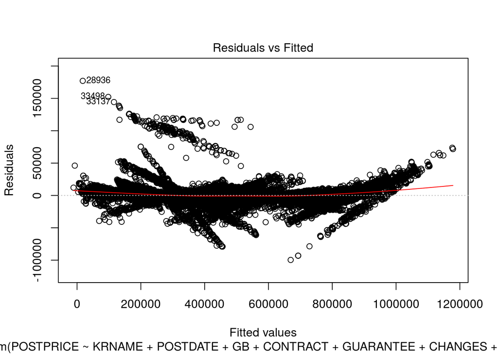

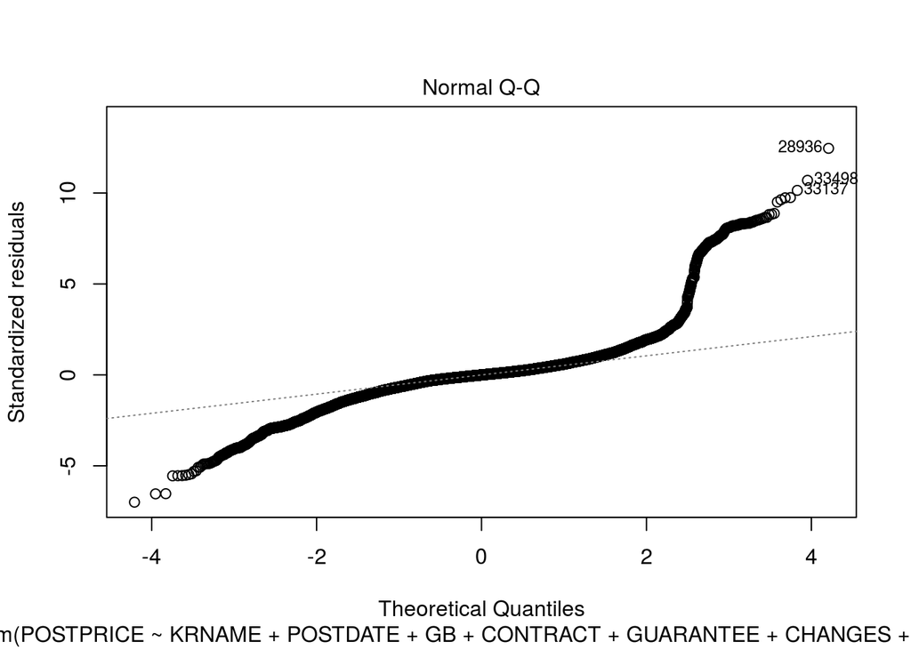

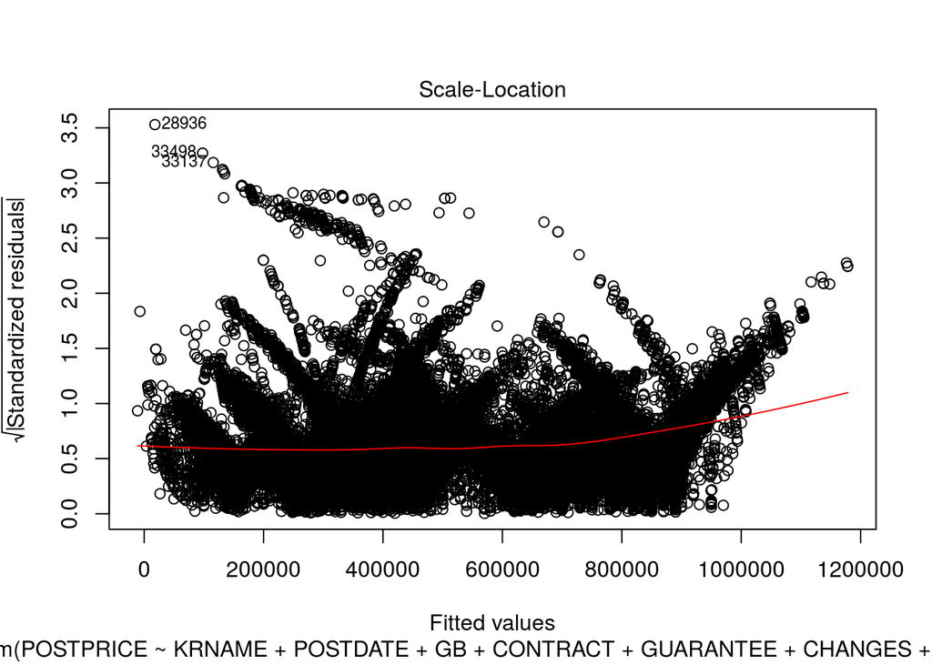

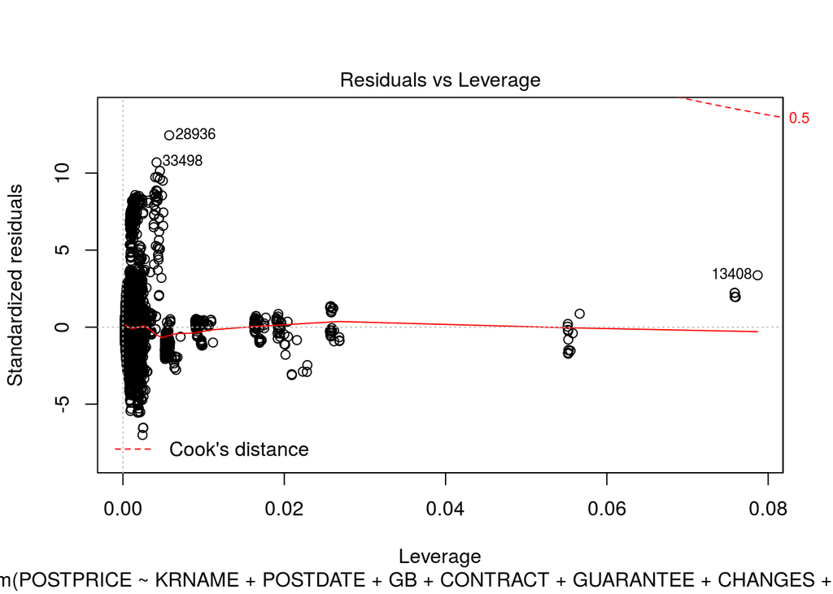

```r
plot(lm.fit)
```

Residuals VS Fitted plot을 보면 일정한 패턴을 보이며 0을 기준으로 고루 퍼져있지 않다. - 등분산성 위배

Normal Q-Q plot 을 보면 직선형태가 아닌 S자 형태를 보인다. - 정규성 위배

### 7. 다중공선성 확인

```r
# library(car)
library(pedometrics)
stepVIF(lm.fit)
```

```
##
## Call:
## lm(formula = POSTPRICE ~ KRNAME + POSTDATE + GB + CONTRACT +
##     GUARANTEE + CHANGES + CONDITIONS + COMPONENT + SOLD, data = data1)
##
## Coefficients:
##                       (Intercept)                     KRNAME아이폰 4
##                            317643                              16777
##                   KRNAME아이폰 4S                     KRNAME아이폰 5
##                             31540                              42915
##                   KRNAME아이폰 5C                    KRNAME아이폰 5S
##                             86357                             106758
##                    KRNAME아이폰 6              KRNAME아이폰 6 플러스
##                            191158                             267832
##                   KRNAME아이폰 6S             KRNAME아이폰 6S 플러스
##                            302494                             376056
##                    KRNAME아이폰 7              KRNAME아이폰 7 플러스
##                            501065                             629999
##                   KRNAME아이폰 SE                           POSTDATE
##                            218613                             -97254
##                            GB16GB                            GB256GB
##                           -131741                              90035
##                            GB32GB                             GB64GB
##                            -98891                             -63474
##                             GB8GB          CONTRACT요금할인약정 가능
##                           -137690                               5539
##         CONTRACT요금할인약정 불가       GUARANTEE무상 보증기간 만료
##                              3799                             -10697
##                  GUARANTEE미확인                     CHANGES확정기변
##                             -9999                             -11735
##  CONDITIONS상(새제품 수준/무흠집)    CONDITIONS중 (생활흠집 외 양호)
##                            -74387                            -101315
##      CONDITIONS하(번인/잔상/파손)    COMPONENT단품 (기기본체만 있음)
##                           -146959                              17368
## COMPONENT박스 및 모든 구성품 포함                            SOLDyes
##                             18346                              -6057
```

stepVIF로 다중공선성을 띄고 있는 변수들을 제거한 결과 유의한 변수는

POSTPRICE ~ KRNAME + POSTDATE + GB + CONTRACT + GUARANTEE + CHANGES + CONDITIONS + COMPONENT + SOLD로 나타났다.

### 8. 다중공선성이 있는 변수 제거 후 다항회귀분석

```r
lm.fit2 <- lm(formula(stepVIF(lm.fit)), data=data1)
```

### 9. 최적의 회귀분석모델을 얻기 위해 STEPWISE 실시

```r
lm.fit.step <- step(lm.fit2, direction="both")
```

```
## Start:  AIC=835938.8
## POSTPRICE ~ KRNAME + POSTDATE + GB + CONTRACT + GUARANTEE + CHANGES +
##     CONDITIONS + COMPONENT + SOLD
##
##              Df  Sum of Sq        RSS    AIC
## <none>                     8.3038e+13 835939
## - CONTRACT    2 1.6675e+11 8.3205e+13 836013
## - SOLD        1 3.0818e+11 8.3346e+13 836081
## - GUARANTEE   2 3.7594e+11 8.3414e+13 836111
## - CHANGES     1 5.3595e+11 8.3574e+13 836187
## - COMPONENT   2 2.4253e+12 8.5463e+13 837055
## - POSTDATE    1 2.1881e+13 1.0492e+14 845038
## - CONDITIONS  3 3.4280e+13 1.1732e+14 849380
## - GB          5 5.6650e+13 1.3969e+14 856167
## - KRNAME     12 3.5019e+14 4.3322e+14 900196
```

최종적으로 선택된 설명변수는 다음과 같다.

```r
formula(lm.fit.step)
```

```
## POSTPRICE ~ KRNAME + POSTDATE + GB + CONTRACT + GUARANTEE + CHANGES +
##     CONDITIONS + COMPONENT + SOLD
```

### 10. STEPWISE를 통해 최종적으로 선택된 변수로 최상의 회귀분석 실행

```r
lm.fit.best <- lm(formula(lm.fit.step), data=data1)
summary(lm.fit.best)
```

```
##
## Call:
## lm(formula = formula(lm.fit.step), data = data1)
##
## Residuals:
##     Min      1Q  Median      3Q     Max
## -330863  -26864     -40   26536  324895
##
## Coefficients:
##                                    Estimate Std. Error  t value Pr(>|t|)
## (Intercept)                        317642.8     7492.7   42.394  < 2e-16
## KRNAME아이폰 4                      16777.1     8512.4    1.971 0.048741
## KRNAME아이폰 4S                     31540.2     9143.1    3.450 0.000562
## KRNAME아이폰 5                      42915.1     7605.7    5.642 1.69e-08
## KRNAME아이폰 5C                     86357.4     9744.5    8.862  < 2e-16
## KRNAME아이폰 5S                    106757.6     7448.2   14.333  < 2e-16
## KRNAME아이폰 6                     191158.3     7396.0   25.846  < 2e-16
## KRNAME아이폰 6 플러스              267831.7     7443.5   35.982  < 2e-16
## KRNAME아이폰 6S                    302494.4     7413.4   40.803  < 2e-16
## KRNAME아이폰 6S 플러스             376055.7     7443.4   50.522  < 2e-16
## KRNAME아이폰 7                     501065.0     7433.7   67.404  < 2e-16
## KRNAME아이폰 7 플러스              629998.5     7449.2   84.573  < 2e-16
## KRNAME아이폰 SE                    218613.2     7480.7   29.224  < 2e-16
## POSTDATE                           -97254.0      960.8 -101.222  < 2e-16
## GB16GB                            -131741.0     1239.1 -106.316  < 2e-16
## GB256GB                             90034.6     1858.5   48.444  < 2e-16
## GB32GB                             -98890.7      857.2 -115.367  < 2e-16
## GB64GB                             -63474.2     1241.3  -51.137  < 2e-16
## GB8GB                             -137689.6    12045.7  -11.431  < 2e-16
## CONTRACT요금할인약정 가능            5538.7      629.0    8.806  < 2e-16
## CONTRACT요금할인약정 불가            3798.5      842.1    4.511 6.48e-06
## GUARANTEE무상 보증기간 만료        -10697.4      836.7  -12.786  < 2e-16
## GUARANTEE미확인                     -9998.5     1040.3   -9.611  < 2e-16
## CHANGES확정기변                    -11734.7      740.8  -15.842  < 2e-16
## CONDITIONS상(새제품 수준/무흠집)   -74386.7      704.8 -105.539  < 2e-16
## CONDITIONS중 (생활흠집 외 양호)   -101315.4      863.3 -117.352  < 2e-16
## CONDITIONS하(번인/잔상/파손)      -146958.9     1834.0  -80.131  < 2e-16
## COMPONENT단품 (기기본체만 있음)     17368.0     1283.7   13.530  < 2e-16
## COMPONENT박스 및 모든 구성품 포함   18345.6      563.1   32.581  < 2e-16
## SOLDyes                             -6057.3      504.2  -12.013  < 2e-16
```

[output cut: 22 more lines]

```
## GUARANTEE무상 보증기간 만료       ***
## GUARANTEE미확인                   ***
## CHANGES확정기변                   ***
## CONDITIONS상(새제품 수준/무흠집)  ***
## CONDITIONS중 (생활흠집 외 양호)   ***
## CONDITIONS하(번인/잔상/파손)      ***
## COMPONENT단품 (기기본체만 있음)   ***
## COMPONENT박스 및 모든 구성품 포함 ***
## SOLDyes                           ***
## ---
## Signif. codes:  0 '***' 0.001 '**' 0.01 '*' 0.05 '.' 0.1 ' ' 1
##
## Residual standard error: 46210 on 38882 degrees of freedom
## Multiple R-squared:  0.9656, Adjusted R-squared:  0.9656
## F-statistic: 3.763e+04 on 29 and 38882 DF,  p-value: < 2.2e-16
```

최종적으로 회귀분석 실시한 결과 p-value: < 2.2e-16로 회귀모델은 유의하다고 판단할 수 있다.

도출된 회귀식은

Y(중고판매가격) = 317642.8 + 16777.1(아이폰 4) + 31540.2(아이폰 4S) + 42915.1(아이폰 5) + 86357.4(아이폰 5C) + 106757.6(아이폰 5S) + 191158.3(아이폰 6) + 267831.7(아이폰 6 플러스) + 302494.4(아이폰 6S) + 376055.7(아이폰 6S 플러스) + 501065(아이폰 7) + 629998.5(아이폰 7 플러스) + 218613.2(아이폰 SE) - 97254(POSTDATE) - 131741(16GB) + 90034.6(256GB) - 98890.7(32GB) - 63474.2(64GB) - 137689.6(8GB) + 5538.7(요금할인약정 가능) + 3798.5(요금할인약정 불가) - 10697.4(무상 보증기간 만료) -9998.5(미확인) - 11734.7(확정기변) - 74386.7(CONDITION 상) - 101315.4(CONDITION 중) - 146958.9(CONDITION 하) + 17368.0(기기본체만 있음) + 18345.6(모든 구성품 포함) - 6057.3(SOLD YES)

### 11. 잔차 확인

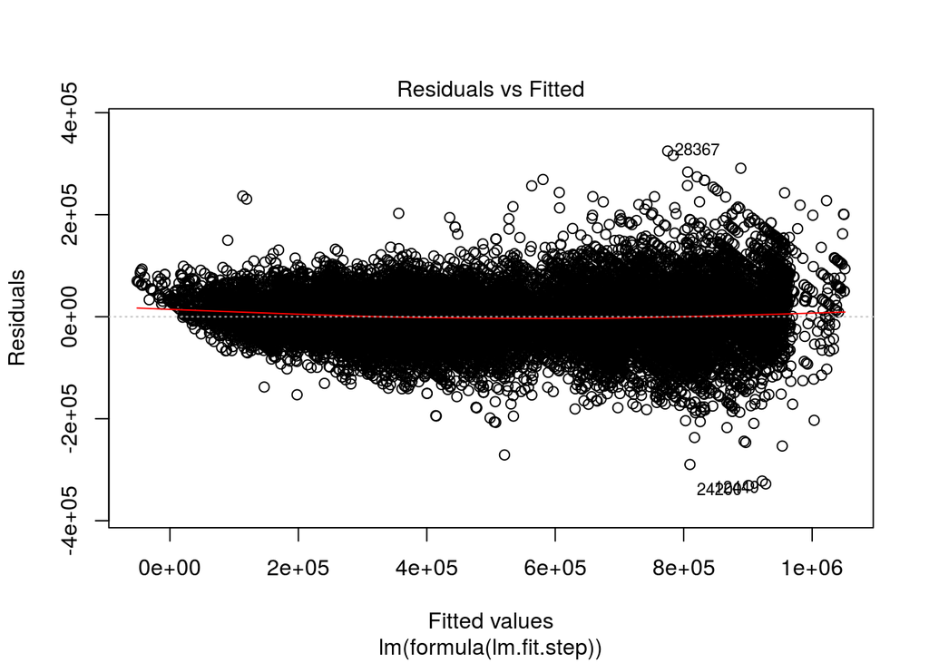

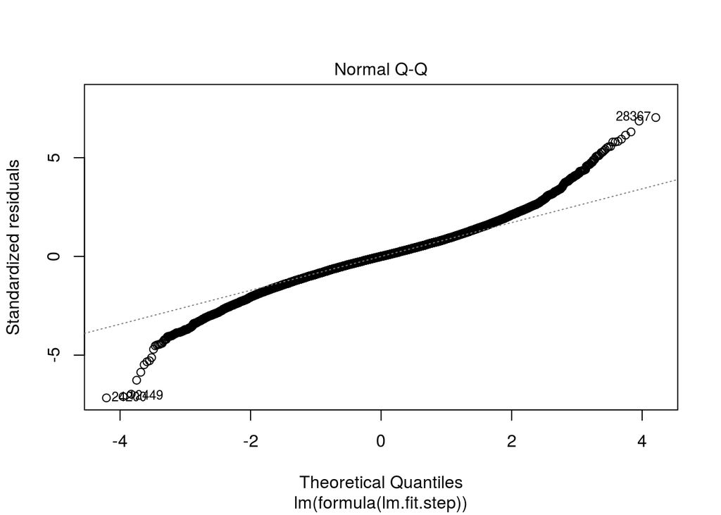

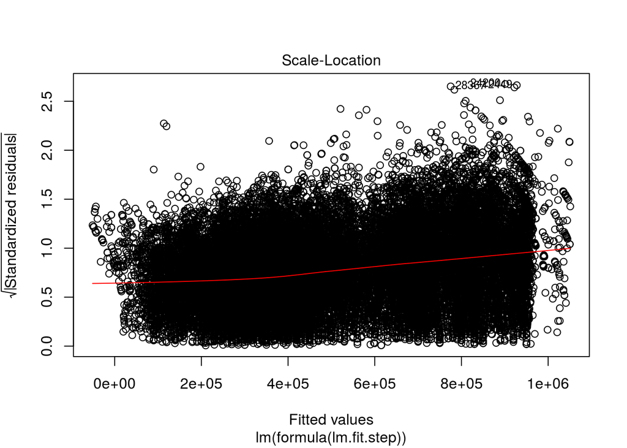

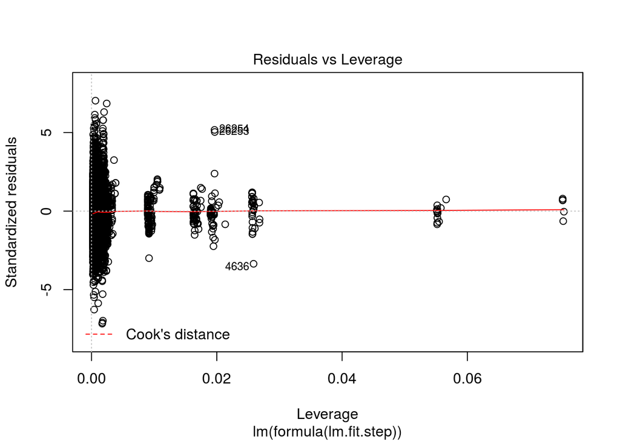

```r
plot(lm.fit.best)
```

초기 회귀분석과는 다르게 이상적인 모습은 아니지만 잔차가 정규성과 등분산성을 어느정도 띄고 있는 것을 확인할 수 있다.

### 12. 잔차 검증

```r
# 독립성 검증
library(lmtest)
dwtest(lm.fit.best)
```

```
##
##  Durbin-Watson test
##
## data:  lm.fit.best
## DW = 1.849, p-value < 2.2e-16
## alternative hypothesis: true autocorrelation is greater than 0
```

```r
# 정규성 검증
shapiro.test(sample(resid(lm.fit.best), 5000))
```

```
##
##  Shapiro-Wilk normality test
##
## data:  sample(resid(lm.fit.best), 5000)
## W = 0.9875, p-value < 2.2e-16
```

독립성 검증인 Durbin-Watson test 경우 p-value < 2.2e-16로 자기상관을 띈다고도 볼 수 있지만 해석에 따라 DW값이 2에 가까우면 독립성을 만족하다고 볼 수 도 있다.

정규성 검증인 Shapiro-Wilk normality test 경우 p-value < 2.2e-16로 잔차가 정규성을 만족하지 않는 것을 확인 할 수 있다.

이는 표본 수가 부족하거나 데이터에 이상치들이 존재한다고 생각 할 수 있다.